# Lesser Yellowlegs Integrated Population Model

- Show All Code
- Hide All Code
- View Source

Anchorage breeding population — results summary

Published

4 November 2026

**NoteHow to read this report**

Abundance is estimated on a **relative** scale — the counts are a volunteer index, not a census. Read the *shape* of the trajectory and the growth rate $\lambda$; the absolute number of birds is not identified and is not reported here.

Recruitment (`psi1`, `psi2`) is a **composite** probability: survive **and** return to breed locally. It is not juvenile survival, and should not be compared against published juvenile survival estimates.

# 1 Overview

This integrated population model combines three data sources into one likelihood so that each informs a shared set of demographic rates.

Table 1

Data sources

| Source | Data | Years | Detail |
| --- | --- | --- | --- |
| Abundance | Volunteer wetland counts | 2014–2026 | 780 records, 27 wetlands, 3 weekly visits |
| Survival | Adult mark–resight (CJS) | 2010–2026 | 212 individuals, sex + tag-type covariates |
| Productivity | Nest productivity | 2018–2026 | 77 nests, chicks per nest |

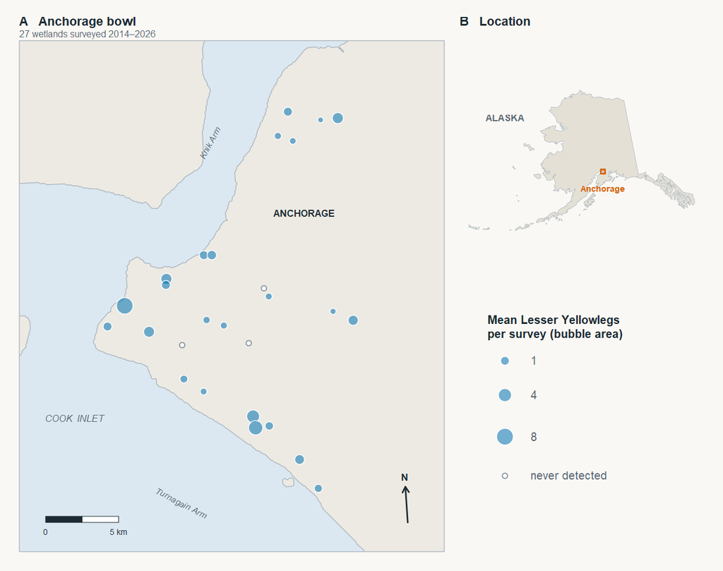

Figure 1: Study area. **A** The Anchorage bowl, with the 27 wetlands in the IPM’s count stream; the mark–resight and nest monitoring also sit here. The five distant wetlands in the volunteer survey are surveyed but not fitted, and are not shown (see below). Bubble area is the mean number of Lesser Yellowlegs per survey — a raw count, not an abundance estimate, and uncorrected for detection, effort or wetland area. Hollow circles are wetlands that have never produced a detection. Site coordinates are in `manuscript/figures/study_area_sites.csv`. **B** Location in Alaska. Shoreline from GSHHG full resolution (Wessel & Smith 1996).

**NoteThe counts cover the same ground as the demographic data — deliberately**

The volunteer survey covers 32 wetlands across roughly 67 km of upper Cook Inlet, but every marked bird and every monitored nest comes from the Anchorage bowl (Figure 1). Fitting all 32 would make λ a statement about a wider population than the survival and productivity estimates meant to explain it, and the decomposition further down this report would be comparing the two. Since 2026-11-04 the count stream is restricted to the 27 wetlands in the bowl, dropping both Palmer Hay Flats accesses, Eklutna, Big Lake and Lynn Fuller’s Ponds — 37–67 km out, and 22.6% of all birds counted. They are not drawn in Figure 1.

**The restriction makes the decline steeper, not weaker:** λ 0.939 → 0.930, with P(λ < 1) = 0.997 either way. The wider-area fit is kept as a sensitivity. The list and reasoning are at the top of `scripts/LEYE_IPM.R`.

Recruitment carries a **two-year lag**: chicks are absent from the breeding site until they recruit, and chick data from both eras show recruitment split roughly evenly between ages 1 and 2. Recruits enter the breeding class directly, so there is no separate juvenile stage — volunteer counts cannot distinguish non-breeding age-1 birds from breeding adults. The full formulation follows.

# 2 Model structure

## 2.1 Life cycle and data sources

[figure not shown]

Figure 2: Life cycle of the modeled population. Boxes are states, arrows are the demographic rates that move birds between them, and the colours identify which data source informs each rate. `psi1` and `psi2` are composite survive-and-return-locally probabilities, not annual survival: a bird that survives but settles elsewhere is not a local recruit.

## 2.2 Model graph

[figure not shown]

Figure 3: Directed graph of the integrated model, in the style of Kéry & Schaub. Shaded nodes are observed data, unshaded nodes are estimated quantities, and the three observation submodels all attach to the same latent series of breeding adults `N`. That shared state is what makes this an integrated model rather than three analyses reported together.

## 2.3 Statistical formulation

Transcribed from `scripts/LEYE_IPM.R`. Indices: $t$ = year (1…$T$, 2014–2026), $i$ = count record, $j$ = marked individual, $m$ = nest, $w$ = survey week, $k$ = wetland.

**Process model.** Two free initial years, because recruitment lags two years and there is nothing to build $N_1$ and $N_2$ from:

$$\begin{aligned}
N_1,\, N_2 &\sim \mathrm{Normal}(0,\ 50)\ \text{truncated at } 0 \\[2pt]
R_t &\sim \mathrm{Poisson}\!\left(N_{t-1}\,\frac{f_{t-1}}{2}\,\psi_1
\;+\; N_{t-2}\,\frac{f_{t-2}}{2}\,\psi_2\right) \\[2pt]
S_t &\sim \mathrm{Poisson}\!\left(N_{t-1}\,\phi_{t-1}\right) \\[2pt]
I_t &\sim \mathrm{Poisson}\!\left(N_{t-1}\,\omega\right) \\[2pt]
N_t &= S_t + R_t + I_t \\[2pt]
\lambda_t &= N_{t+1} \,/\, N_t
\end{aligned}
\qquad t = 3,\dots,T$$

**Vital rates.**

$$\begin{aligned}
\operatorname{logit} \phi_t &= \mu_\phi + \varepsilon_{\phi,t},
&\varepsilon_{\phi,t} &\sim \mathrm{Normal}(0,\ \sigma_\phi)
&&\text{adult survival} \\[2pt]
\operatorname{logit} s_t &= \mu_s + \varepsilon_{s,t},
&\varepsilon_{s,t} &\sim \mathrm{Normal}(0,\ \sigma_s)
&&\text{nest success} \\[2pt]
f_t &= s_t \cdot C \cdot q &&&&\text{fledglings per pair} \\[2pt]
\psi_1 &= \pi\,\kappa &&&&\text{recruit at age 1} \\[2pt]
\psi_2 &= \pi\,(1-\kappa) &&&&\text{recruit at age 2}
\end{aligned}$$

with $C = 4$ (modal clutch) and $q$ the per-egg fledging probability. The immigration rate $\omega$ is constant, so it contributes nothing to *variation* in $\lambda$ by construction — see Section 8.2.

**Observation 1 · counts** (relative index):

$$\begin{aligned}
\log \mu_i &= \beta_0 + \log N_{t(i)} + \text{week}_{w(i)}
+ b_e E^{(1)}_i + b_d E^{(2)}_i + u_{k(i)} + \delta_i \\[2pt]
\text{count}_i &\sim \mathrm{Poisson}(\mu_i) \\[2pt]
u_k &\sim \mathrm{Normal}(0,\ \sigma_{\text{site}})
&&\text{wetland random effect} \\[2pt]
\delta_i &\sim \mathrm{Normal}(0,\ \sigma_{\text{od}})
&&\text{overdispersion}
\end{aligned}$$

$\beta_0$ is deliberately non-identifiable against the level of $N$. Expect poor convergence for it, and read abundance as shape rather than magnitude.

**Observation 2 · mark–resight** (CJS with latent alive-state $z$):

$$\begin{aligned}
\operatorname{logit} \phi_{j,t} &= \ell_\phi\!\left[\mathrm{lookup}(t)\right]
+ \beta^{\text{sex}}_{\mathrm{sex}(j)} + \beta^{\text{tag}}_{\mathrm{tag}(j)} \\[2pt]
\operatorname{logit} p_j &= p_0 + \beta^{p}_{\mathrm{tag}(j)} \\[2pt]
z_{j,t} &\sim \mathrm{Bernoulli}\!\left(\phi_{j,t-1}\, z_{j,t-1}\right),
\qquad z_{j,\,f(j)} = 1 \\[2pt]
y_{j,t} &\sim \mathrm{Bernoulli}\!\left(p_j\, z_{j,t}\right)
\end{aligned}$$

$$\ell_\phi[1{:}T-1] = \operatorname{logit}\phi_t, \qquad
\ell_\phi[T] = \operatorname{logit}\phi_{\text{pre}}, \qquad
\ell_\phi[T+1] = \operatorname{logit}\phi_{\text{post}}$$

The two overflow slots absorb the mark–resight intervals that fall outside the count series, rather than discarding those birds.

**Observation 3 · productivity** (two-part):

$$\begin{aligned}
\text{succ}_m &\sim \mathrm{Bernoulli}\!\left(s_{t(m)}\right)
&&\text{did the nest fledge anything?} \\[2pt]
\text{chicks}_m &\sim \mathrm{Binomial}\!\left(C,\ q \cdot \text{succ}_m\right)
&&\text{how many of the clutch}
\end{aligned}$$

A single Poisson was rejected here: the brood-size data are bimodal, with nests fledging zero, two, three or four chicks but never exactly one.

**Priors.**

$$\begin{aligned}
\mu_\phi,\ \mu_s,\ p_0,\ \beta^{\text{sex}},\ \beta^{\text{tag}},\ \beta^{p}
&\sim \mathrm{Normal}(0,\ 1.5) \\[2pt]
\beta_0,\ b_e,\ b_d,\ \text{week}_w &\sim \mathrm{Normal}(0,\ 5) \\[2pt]
\sigma_\phi &\sim \mathrm{Exponential}(2) \\[2pt]
\sigma_s,\ \sigma_{\text{site}},\ \sigma_{\text{od}},\ \omega
&\sim \mathrm{Exponential}(1) \\[2pt]
\phi_{\text{pre}},\ \phi_{\text{post}},\ q &\sim \mathrm{Uniform}(0,\ 1) \\[2pt]
\pi &\sim \mathrm{Beta}(1.8410,\ 32.5058)
&&\text{modern-era recruitment} \\[2pt]
\kappa &\sim \mathrm{Beta}(7.6338,\ 8.6569)
&&\text{age-1 fraction, both eras}
\end{aligned}$$

$\pi$ and $\kappa$ are the **only** informative priors. Both come from `scripts/LEYE_recruitment_two_era.R` and are passed to the model as constants, so the vague-prior sensitivity run in Section 9.3 is a configuration change rather than a second copy of the model.

# 3 Headline results

0.930

Population growth (λ)

0.884 – 0.977 | -7.0%/yr

0.66

Adult survival

annual, untagged female baseline

0.051

Local recruitment

ψ₁ 0.024 ψ₂ 0.027

0.143

Immigration rate (ω)

65% of annual gains

The population is declining at roughly 7.0% per year. Adult survival is the best-determined rate in the model. Local recruitment is low, and a substantial share of annual gains is attributable to immigration — but see Recruitment versus immigration for why that split remains uncertain.

# 4 Population trajectory

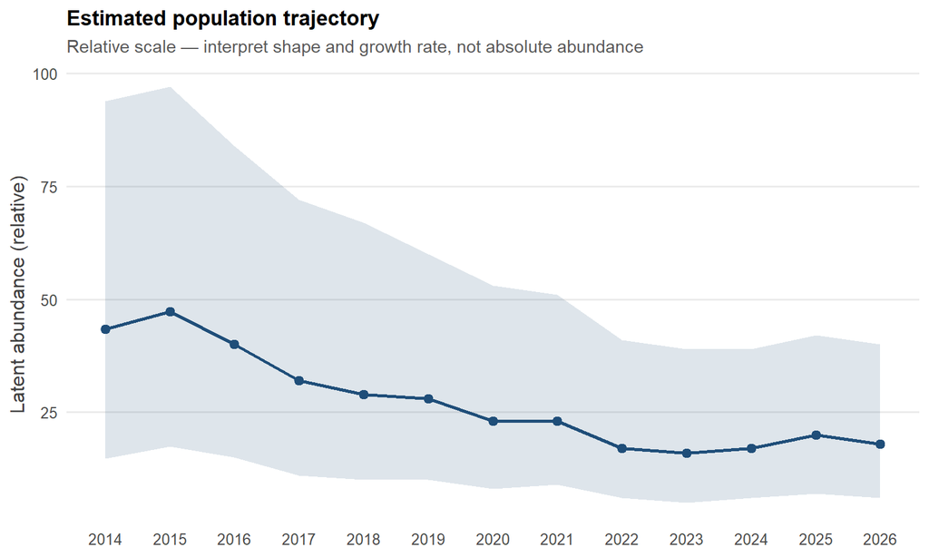

Figure 4: Estimated breeding population on a relative scale. Ribbon is the 95% credible interval. The absolute level is not identified — read the shape, not the height.

```r
Nt <- as.data.frame(qq("N_tot", 1:T))
Nt$year <- ipm_years

ggplot(Nt, aes(year, med)) +
  geom_ribbon(aes(ymin = lwr, ymax = upr), fill = COL_AD, alpha = .15) +
  geom_line(colour = COL_AD, linewidth = .9) +
  geom_point(colour = COL_AD, size = 2.2) +
  scale_x_continuous(breaks = ipm_years) +
  labs(
    title = "Estimated population trajectory",
    subtitle = "Relative scale — interpret shape and growth rate, not absolute abundance",
    x = NULL, y = "Latent abundance (relative)"
  ) +
  theme_leye()
```

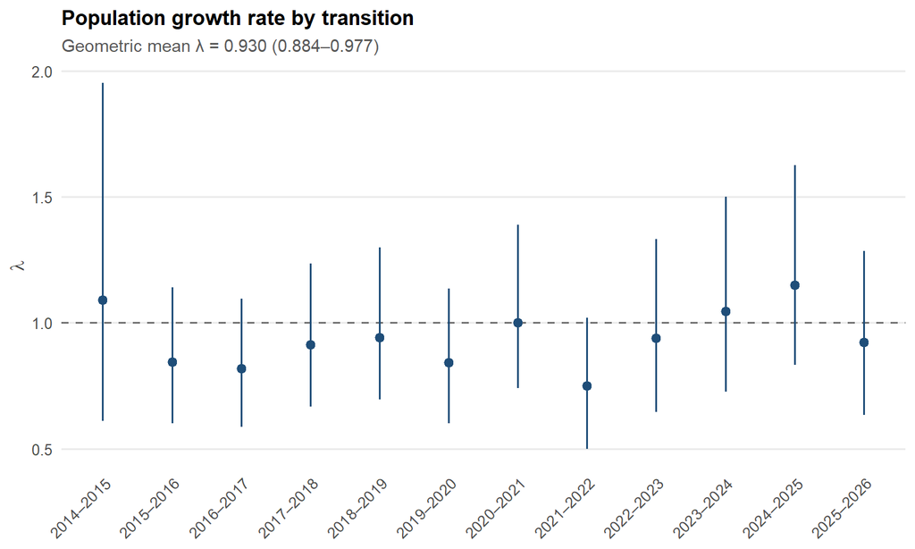

Figure 5: Annual population growth rate. Values below 1 indicate decline. The dashed line marks a stable population.

```r
lamd <- as.data.frame(qq("lambda", 1:(T - 1)))
lamd$transition <- factor(trans_lab, levels = trans_lab)

ggplot(lamd, aes(transition, med)) +
  geom_hline(yintercept = 1, linetype = 2, colour = "grey45") +
  geom_linerange(aes(ymin = lwr, ymax = upr), colour = COL_AD, linewidth = .7) +
  geom_point(colour = COL_AD, size = 2.2) +
  labs(
    title = "Population growth rate by transition",
    subtitle = sprintf("Geometric mean λ = %.3f (%.3f–%.3f)", geolam, geolam_ci[1], geolam_ci[2]),
    x = NULL, y = expression(lambda)
  ) +
  theme_leye() +
  theme(axis.text.x = element_text(angle = 45, hjust = 1))
```

# 5 Adult survival

`phi_ad` is the baseline rate for **untagged females** — the reference level, and the rate that drives the population process model, since the population is overwhelmingly untagged.

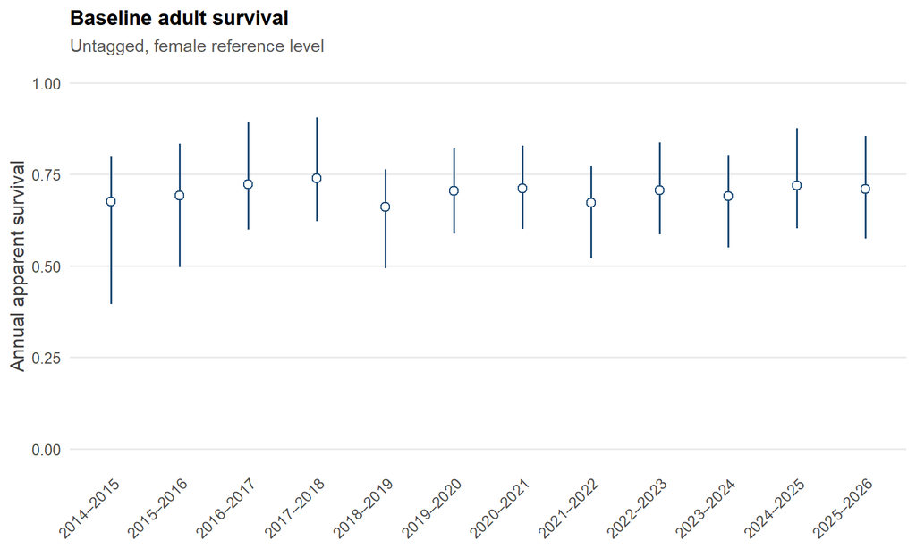

Figure 6: Baseline annual adult survival (untagged female). Open points mark transitions with no direct mark–resight data, informed only through the process model.

```r
ad <- as.data.frame(qq("phi_ad", 1:(T - 1)))
ad$transition <- factor(trans_lab, levels = trans_lab)
ad$has_cjs <- trans_yr %in% cjs_int_start

ggplot(ad, aes(transition, med)) +
  geom_linerange(aes(ymin = lwr, ymax = upr), colour = COL_AD, linewidth = .7) +
  geom_point(aes(shape = has_cjs), colour = COL_AD, fill = "white", size = 2.4) +
  scale_shape_manual(values = c(`TRUE` = 21, `FALSE` = 1), guide = "none") +
  scale_y_continuous(limits = c(0, 1)) +
  labs(
    title = "Baseline adult survival",
    subtitle = "Untagged, female reference level",
    x = NULL, y = "Annual apparent survival"
  ) +
  theme_leye() +
  theme(axis.text.x = element_text(angle = 45, hjust = 1))
```

## 5.1 Covariate effects

Effects are shown as odds ratios against the reference levels (female, untagged). An odds ratio below 1 means lower survival — or lower resighting probability — than the reference.

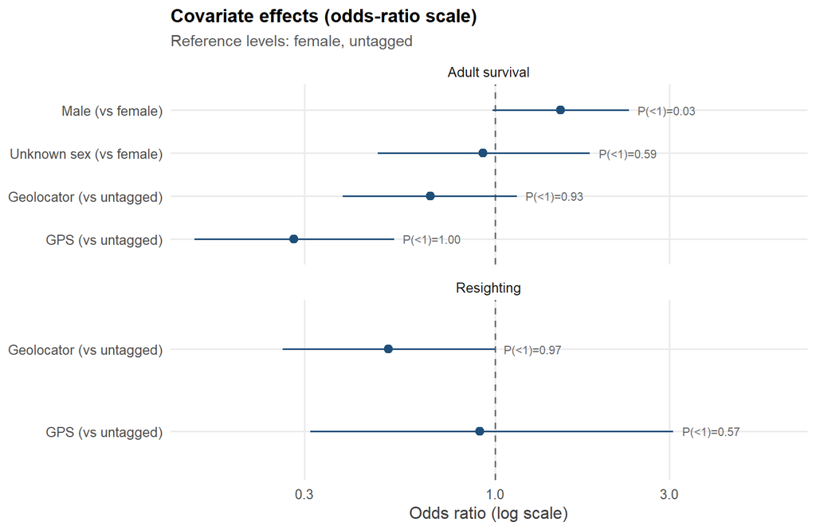

Figure 7: Sex and tag-type effects on survival and resighting. Bars are 95% credible intervals; the dashed line at 1 is no effect.

```r
orq <- function(col, label, panel) {
  x <- exp(mat[, col])
  data.frame(
    term = label, panel = panel,
    med = median(x),
    lwr = quantile(x, .025, names = FALSE),
    upr = quantile(x, .975, names = FALSE),
    pneg = mean(mat[, col] < 0)
  )
}
fo <- rbind(
  orq("bSex_phi[2]", "Male (vs female)", "Adult survival"),
  orq("bSex_phi[3]", "Unknown sex (vs female)", "Adult survival"),
  orq("bTag_phi[2]", "Geolocator (vs untagged)", "Adult survival"),
  orq("bTag_phi[3]", "GPS (vs untagged)", "Adult survival"),
  orq("bTag_p[2]", "Geolocator (vs untagged)", "Resighting"),
  orq("bTag_p[3]", "GPS (vs untagged)", "Resighting")
)
fo$term <- factor(fo$term, levels = rev(unique(fo$term)))

ggplot(fo, aes(med, term)) +
  geom_vline(xintercept = 1, linetype = 2, colour = "grey45") +
  geom_linerange(aes(xmin = lwr, xmax = upr), colour = COL_AD, linewidth = .7) +
  geom_point(colour = COL_AD, size = 2.4) +
  geom_text(aes(x = upr, label = sprintf("P(<1)=%.2f", pneg)),
    hjust = -0.15, size = 2.9, colour = "grey40"
  ) +
  scale_x_log10(expand = expansion(mult = c(.05, .28))) +
  facet_wrap(~panel, ncol = 1, scales = "free_y") +
  labs(
    title = "Covariate effects (odds-ratio scale)",
    subtitle = "Reference levels: female, untagged",
    x = "Odds ratio (log scale)", y = NULL
  ) +
  theme_leye() +
  theme(panel.grid.major.x = element_line(colour = "grey92"))
```

Table 2

Adult survival by sex and tag type

First transition. GPS × unknown-sex has no supporting data.

| Sex | Tag | Estimate | Lower | Upper |
| --- | --- | --- | --- | --- |
| Female | None | 0.656 | 0.396 | 0.798 |
| Female | Geolocator | 0.562 | 0.282 | 0.745 |
| Female | GPS | 0.362 | 0.144 | 0.565 |
| Male | None | 0.739 | 0.499 | 0.860 |
| Male | Geolocator | 0.655 | 0.380 | 0.813 |
| Male | GPS | 0.457 | 0.207 | 0.667 |
| Unknown | None | 0.638 | 0.378 | 0.807 |
| Unknown | Geolocator | 0.544 | 0.282 | 0.742 |
| Unknown | GPS | 0.347 | 0.131 | 0.584 |

# 6 Recruitment and immigration

## 6.1 Local recruitment

`psi1` and `psi2` are the probabilities that a fledged chick survives **and** returns to breed locally, at age 1 and age 2 respectively. Their priors come from a separate two-era analysis of banded chick cohorts (`scripts/LEYE_recruitment_two_era.R`, which supersedes the 1990s-only `LEYE_juv90_module.R`) and are informative but free to update. The level is taken from the modern era; the age-1 versus age-2 split is estimated across both.

Table 3

Local recruitment

Composite survival × philopatry — not annual survival

| Parameter | Mean | Lower | Upper |
| --- | --- | --- | --- |
| pi_rec (total) | 0.051 | 0.006 | 0.134 |
| kappa (fraction at age 1) | 0.466 | 0.237 | 0.703 |
| psi1 (age 1) | 0.024 | 0.003 | 0.068 |
| psi2 (age 2) | 0.027 | 0.003 | 0.077 |

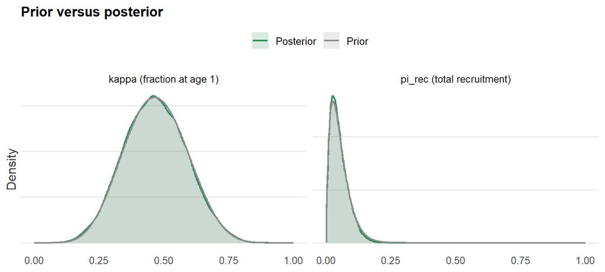

Figure 8: Prior versus posterior for the two recruitment parameters. Movement away from the prior would show the count data carrying information about recruitment; the near-complete overlap shows that it carries very little, and that these estimates rest on the chick analysis that supplied the priors.

```r
grid_x <- seq(0, 1, length.out = 512)
dens <- function(nm, a, b, lab) {
  po <- density(mat[, nm], from = 0, to = 1)
  rbind(
    data.frame(x = grid_x, y = dbeta(grid_x, a, b), which = "Prior", par = lab),
    data.frame(x = po$x, y = po$y, which = "Posterior", par = lab)
  )
}
dd <- rbind(
  dens("pi_rec", PRIOR_PI["a"], PRIOR_PI["b"], "pi_rec (total recruitment)"),
  dens("kappa", PRIOR_KAPPA["a"], PRIOR_KAPPA["b"], "kappa (fraction at age 1)")
)

ggplot(dd, aes(x, y, colour = which, fill = which)) +
  geom_area(position = "identity", alpha = .18, colour = NA) +
  geom_line(linewidth = .8) +
  facet_wrap(~par, scales = "free") +
  scale_colour_manual(values = c(Prior = "grey55", Posterior = COL_REC), name = NULL) +
  scale_fill_manual(values = c(Prior = "grey55", Posterior = COL_REC), name = NULL) +
  labs(title = "Prior versus posterior", x = NULL, y = "Density") +
  theme_leye() +
  theme(legend.position = "top", axis.text.y = element_blank())

# How far each posterior actually moved, in units of its own prior. Quoted
# inline below rather than described in words: this callout previously claimed
# `pi_rec` "moves appreciably from its prior", which was never checked against
# the fit and is not true of any fit in this repository.
#   shift  -- change in mean, expressed in prior SDs
#   narrow -- 1 - sd(posterior)/sd(prior), the share of prior spread the data removed
# unname() first: PRIOR_PI["a"] carries the name "a", and c(m = <named>) builds
# "m.a" rather than "m", so p[["m"]] below would fail.
bmom <- function(a, b) {
  a <- unname(a)
  b <- unname(b)
  c(m = a / (a + b), s = sqrt(a * b / ((a + b)^2 * (a + b + 1))))
}
movement <- function(nm, a, b) {
  p <- bmom(a, b)
  x <- mat[, nm]
  list(shift = (mean(x) - p[["m"]]) / p[["s"]], narrow = 1 - sd(x) / p[["s"]])
}
MOVE <- list(
  pi = movement("pi_rec", PRIOR_PI["a"], PRIOR_PI["b"]),
  kap = movement("kappa", PRIOR_KAPPA["a"], PRIOR_KAPPA["b"])
)
```

**The counts carry almost no information about recruitment, and none about its timing.** Both posteriors sit essentially on top of their priors. `pi_rec` moves -0.07 prior standard deviations and the data remove about 10% of its prior spread — a little information about the recruitment *level*, but not much. `kappa` moves -0.02 prior SDs and its interval is unchanged to the nearest percent: the age-1 versus age-2 split is exactly what the chick analysis put in.

So the recruitment estimates in Table 3 should be read as the chick histories’ answer, lightly updated, not as something the count data established. That matters because those histories are thin — 18 returning birds across two eras, of which the 1997 cohort alone supplies seven (see Caveats) — and because recruitment and immigration enter λ additively, so what the counts cannot separate is absorbed by `omega`.

## 6.2 Has recruitment changed between eras?

The two chick-banding eras are thirty years apart, so the module that supplies the recruitment prior can also be asked whether local recruitment has declined. This is a **candidate result, not a settled one**, and the figure is built to show why.

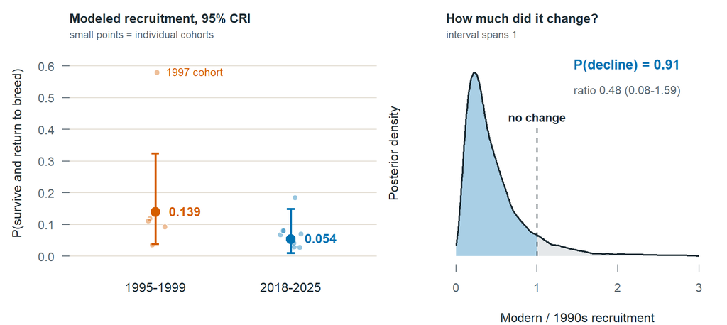

Figure 9: Local recruitment in the two banding eras. Left: modeled probability of surviving and returning to breed, with individual cohorts behind each era estimate. Right: posterior of the ratio between eras; the shaded region below 1 is the posterior probability of a decline.

**Do not report this as an established decline.** The direction is well supported and the magnitude is not: the ratio spans a thirteen-fold drop to a modest increase. The comparison rests on 13 and 5 returning birds, and the 1997 cohort — 7 of 11 chicks — supplies most of the 1990s signal on its own. Note also that the left panel is the *typical* cohort in each era, not the cohort average; see Section 9.3.1.

## 6.3 Recruitment versus immigration

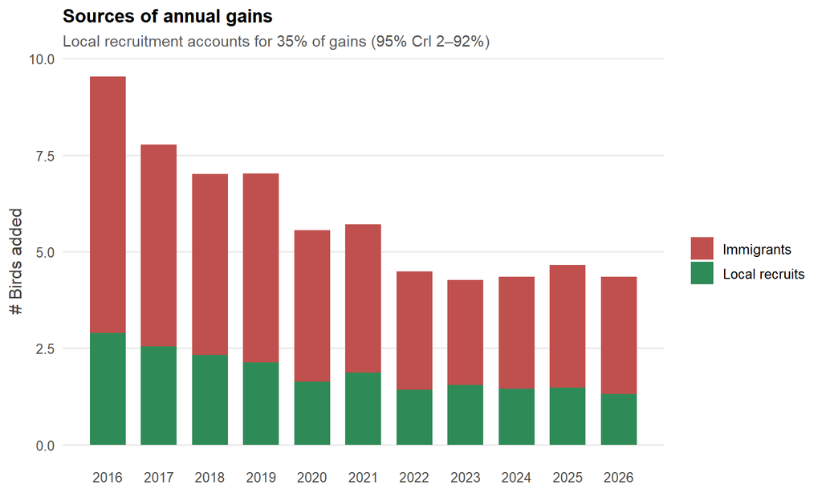

Figure 10: Annual gains to the breeding population, split into locally recruited birds and immigrants. Bar heights are posterior means.

```r
gains <- rbind(
  data.frame(
    year = ipm_years[3:T], source = "Local recruits",
    value = colMeans(mat[, paste0("N_rec[", 3:T, "]")])
  ),
  data.frame(
    year = ipm_years[3:T], source = "Immigrants",
    value = colMeans(mat[, paste0("Imm[", 3:T, "]")])
  )
)

ggplot(gains, aes(year, value, fill = source)) +
  geom_col(position = "stack", width = .7) +
  scale_fill_manual(values = c("Local recruits" = COL_REC, "Immigrants" = COL_IMM), name = NULL) +
  scale_x_continuous(breaks = ipm_years[3:T]) +
  labs(
    title = "Sources of annual gains",
    subtitle = sprintf(
      "Local recruitment accounts for %.0f%% of gains (95%% CrI %.0f–%.0f%%)",
      100 * mean(share), 100 * quantile(share, .025), 100 * quantile(share, .975)
    ),
    x = NULL, y = "# Birds added"
  ) +
  theme_leye()
```

**This split is uncertain.** Recruitment and immigration both add birds, and a relative-scale count index cannot fully separate them. The credible interval on the recruitment share spans 2% to 92%. Informative priors on recruitment narrow this but do not resolve it. Treat the point estimate as indicative, not as a finding.

# 7 Productivity

Chicks per nest are modeled in **two parts**: whether the nest succeeded at all, and how many of a four-egg clutch fledged given that it did.

Nest success averages **0.70** (95% CrI 0.59–0.81) and, given success, each egg fledges with probability **0.89** (0.84–0.93). Mean chicks per nest is the product of the two with clutch size, so `f_rate` keeps the same meaning it had under the earlier single-distribution model and the recruitment equation is unchanged.

This was initially modeled using a single Poisson draw for chicks per nest, but failed the posterior predictive check (see Section 9.2). The observed counts are bimodal — 0, 2, 3 or 4 chicks, with **no nest producing exactly one** — because a four-egg-clutch shorebird usually either loses the nest entirely or fledges a near-full brood. A Poisson cannot generate that shape at any mean; at the observed mean it expects roughly 16 single-chick nests. The two-part model reproduces the observed frequencies closely.

This also tightened productivity in years with few monitored nests, where the old model fitted a free annual mean to as few as two or three nests. The two-part version borrows strength through the shared clutch size and fledging rate.

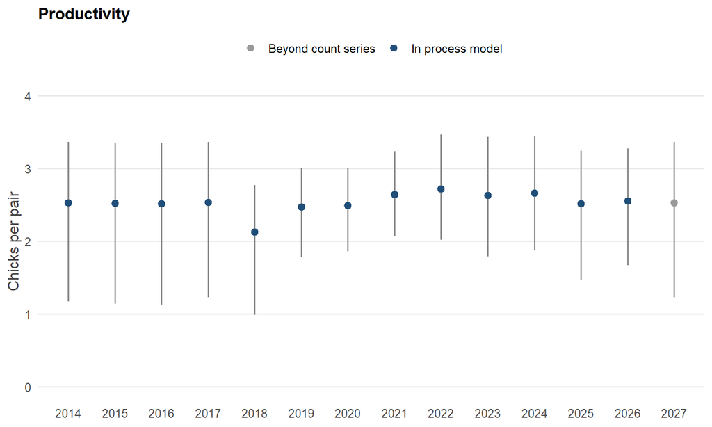

Figure 11: Estimated chicks per pair. The final year is estimated from productivity data that has no matching count year and does not feed the population process.

```r
fr <- as.data.frame(qq("f_rate", 1:(T + 1)))
fr$year <- c(ipm_years, max(ipm_years) + 1)
fr$in_model <- c(rep(TRUE, T), FALSE)

ggplot(fr, aes(year, med)) +
  geom_linerange(aes(ymin = lwr, ymax = upr), colour = "grey55", linewidth = .7) +
  geom_point(aes(colour = in_model), size = 2.2) +
  scale_colour_manual(
    values = c(`TRUE` = COL_AD, `FALSE` = "grey60"),
    labels = c(`TRUE` = "In process model", `FALSE` = "Beyond count series"), name = NULL
  ) +
  scale_x_continuous(breaks = fr$year) +
  scale_y_continuous(limits = c(0,4)) +
  labs(title = "Productivity", x = NULL, y = "Chicks per pair") +
  theme_leye() +
  theme(legend.position = "top")
```

# 8 What drives population change

A transient LTRE (tLTRE), following Koons et al. (2016, 2017). Two questions that sound similar and have different answers:

- **Level** — what *sustains* the population? Mean λ splits across survival, recruitment and immigration.
- **Variance** — what *drives year-to-year variation* in λ?

Everything below is computed per posterior draw, so each contribution carries a credible interval rather than being a point estimate at posterior means.

## 8.1 What sustains the population

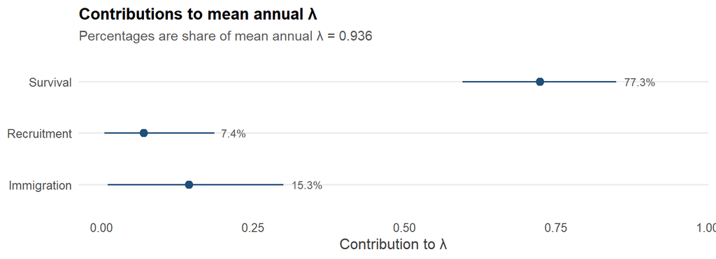

Figure 12: Additive contributions to mean annual λ. Bars are 95% credible intervals; percentages are each pathway’s share of λ. This λ is the arithmetic mean over the transitions the decomposition covers, not the geometric-mean growth rate — see the note below.

```r
lev <- as.data.frame(tl_level)
lev$pathway <- factor(rownames(tl_level), levels = rev(rownames(tl_level)))
# The ARITHMETIC mean lambda, necessarily: this decomposition is additive and
# only the arithmetic mean preserves the identity across years, so the shares
# sum to 100%. It is a larger number than the geometric mean reported as the
# growth rate at the top -- see the note under this figure.
#
# It also covers FEWER transitions: the decomposition needs the previous year's
# productivity, so it starts at s = 2. Both differences are spelled out in the
# note, so compute each one here rather than letting the reader guess which
# accounts for the gap.
lam_mean <- attr(tl_level, "lambda")[["mean"]]
lam_ari_S <- mean(rowMeans(lamt[, tl$S, drop = FALSE]))
lam_geo_S <- mean(exp(rowMeans(log(lamt[, tl$S, drop = FALSE]))))
stopifnot(all.equal(lam_mean, lam_ari_S), ncol(lamt) > length(tl$S))

ggplot(lev, aes(contribution, pathway)) +
  geom_linerange(aes(xmin = lwr, xmax = upr), colour = COL_AD, linewidth = .7) +
  geom_point(colour = COL_AD, size = 2.6) +
  # label at the interval's right edge, not the point, or it lands on the bar
  geom_text(aes(x = upr, label = sprintf("%.1f%%", pct_of_lambda)),
    hjust = -0.25, size = 3.1, colour = "grey35"
  ) +
  scale_x_continuous(expand = expansion(mult = c(.05, .18))) +
  labs(
    title = "Contributions to mean annual λ",
    subtitle = sprintf("Percentages are share of mean annual λ = %.3f", lam_mean),
    x = "Contribution to λ", y = NULL
  ) +
  theme_leye()
```

**Two averages of λ appear in this report, and they differ for two reasons.** This figure’s denominator is 0.936; the growth rate at the top of the report is 0.930.

*Different average.* This figure must average **arithmetically**, because λ<sub>s</sub> = survival + recruitment + immigration holds exactly in each year and only the arithmetic mean preserves that identity — under any other average the pathway shares would not sum to 100%. The headline is the **geometric** mean, the correct summary of multiplicative growth: within each posterior draw it equals (*N*<sub>2026</sub>/*N*<sub>2014</sub>)<sup>1/12</sup> exactly. On this figure’s 11 transitions the two averages are 0.936 and 0.916, so about 0.019 of the gap is the averaging alone.

*Why averaging growth rates overstates growth.* Growth rates multiply rather than add. A population that gains 20% one year and loses 20% the next has λ = 1.2 and λ = 0.8, which average to exactly 1.0 — yet it ends at 1.2 × 0.8 = 0.96 of where it started, a true rate of $\sqrt{0.96} = 0.98$ a year. The arithmetic mean of a set of ratios is never below their geometric mean, and the gap widens as the values scatter: to second order it is about σ²/2 on the log scale, which on these 11 transitions comes to 0.023 against the 0.019 actually observed — the right size, the approximation being exact only in the lognormal limit. This is **Jensen’s inequality**: when a quantity is put through a curved transformation — here a logarithm — averaging before and averaging after give different answers, and the direction is fixed by which way the curve bends.

## 8.2 What drives year-to-year variation

**Most variation in λ is demographic stochasticity, not environmental variation in vital rates.** With roughly 25 birds, Poisson noise in who happens to survive, recruit or arrive is a first-order term. A conventional LTRE reports only the driver contributions and would present a fraction of the variance as though it were the whole story.

Table 4

Partition of Var(λ)

The three sum to 100%. Individual shares can exceed it because the cross term is negative.

| Component | Share of Var(λ) % | Lower | Upper |
| --- | --- | --- | --- |
| Driver-explained | 13.3 | 0.2 | 59.7 |
| Demographic stochasticity | 95.3 | 53.8 | 141.8 |
| Cross term | −8.5 | −80.7 | 23.7 |

The cross term is non-zero because population structure (`ρ`) depends on realized abundance and so carries the same Poisson noise — the smooth and stochastic parts of λ are not independent.

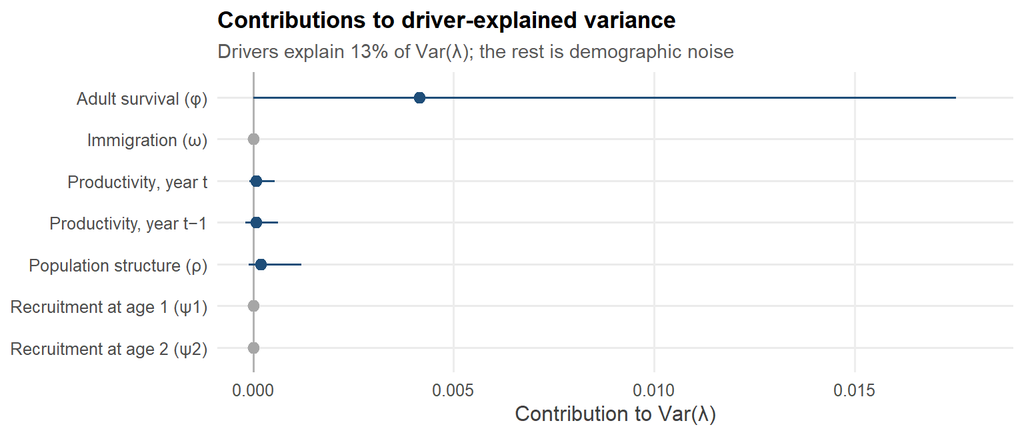

Figure 13: tLTRE contributions to the driver-explained portion of Var(λ). Bars are 95% credible intervals. Parameters with no year index contribute exactly zero by construction.

```r
ct <- as.data.frame(tl_var$contributions)
ct$driver <- rownames(tl_var$contributions)
ct$label <- driver_labs[ct$driver]
ct$structural_zero <- ct$mean == 0 & ct$lwr == 0 & ct$upr == 0
ct$label <- factor(ct$label, levels = rev(ct$label))

ggplot(ct, aes(mean, label)) +
  geom_vline(xintercept = 0, colour = "grey70") +
  geom_linerange(aes(xmin = lwr, xmax = upr, colour = structural_zero), linewidth = .7) +
  geom_point(aes(colour = structural_zero), size = 2.6) +
  scale_colour_manual(
    values = c(`FALSE` = COL_AD, `TRUE` = "grey65"), guide = "none"
  ) +
  # phi's upper bound sits past the default break, so widen or it gets clipped
  scale_x_continuous(expand = expansion(mult = c(.04, .08))) +
  labs(
    title = "Contributions to driver-explained variance",
    subtitle = sprintf(
      "Drivers explain %.0f%% of Var(λ); the rest is demographic noise",
      tl_var$partition_pct["driver_explained", "mean"]
    ),
    x = "Contribution to Var(λ)", y = NULL
  ) +
  theme_leye() +
  theme(panel.grid.major.x = element_line(colour = "grey93"))
```

**Immigration (ω), Recruitment at age 1 (ψ1), Recruitment at age 2 (ψ2)** contribute exactly zero — they are single parameters with no year index, so they cannot vary between years *by construction, not by evidence*. A time-varying immigration rate was fitted and rejected: it absorbed Poisson noise rather than detecting signal (see the README). Separating recruitment from immigration needs data that distinguishes chick-origin returns from newly arrived unbanded adults.

# 9 Model checking

## 9.1 Convergence

Table 5

Convergence diagnostics

3 chains, 21,000 pooled draws

| Parameter | Rhat | Upper |
| --- | --- | --- |
| pi_rec | 1.002 | 1.005 |
| kappa | 1.001 | 1.002 |
| psi1 | 1.001 | 1.003 |
| psi2 | 1.003 | 1.006 |
| omega | 1.003 | 1.013 |
| phi_pre | 1.002 | 1.006 |
| mu_s | 1.001 | 1.005 |
| q_brood | 1.000 | 1.000 |
| sd_s | 1.006 | 1.019 |
| lp_base | 1.000 | 1.001 |
| logB0 | 1.065 | 1.156 |
| bSex_phi[2] | 1.003 | 1.012 |
| bSex_phi[3] | 1.001 | 1.004 |
| bTag_phi[2] | 1.000 | 1.001 |
| bTag_phi[3] | 1.000 | 1.000 |
| bTag_p[2] | 1.000 | 1.000 |
| bTag_p[3] | 1.000 | 1.000 |

Values below 1.05 indicate adequate mixing.

`logB0` is expected to converge poorly. It is the count-model intercept, which is non-identifiable against the absolute level of the population — only their sum enters the linear predictor. This is structural and does not affect $\lambda$ or any rate reported above.

## 9.2 Goodness of fit

An IPM can fit one data source well and another badly, and a single pooled statistic would hide that. Each stream is therefore checked separately, using a Freeman–Tukey discrepancy between the observed data and replicates drawn from the fitted model. The Bayesian *p*-value is P(replicated > observed); values near 0.5 indicate the model reproduces that stream, values near 0 or 1 indicate misfit.

Table 6

Posterior predictive checks

| Stream | Bayesian p |
| --- | --- |
| Counts | 0.479 |
| Productivity | 0.507 |
| Mark–resight | 0.472 |

This check earned its keep. The productivity component originally used a single Poisson and returned *p* = 0.000 — decisive misfit — which led to the two-part nest-success × brood-size model now in use.

Worth noting for anyone repeating this: the productivity data have **variance/mean = 1.18**, so a routine overdispersion check would have passed them. The misfit was in *shape*, not variance, and only a discrepancy measure sensitive to the whole distribution detected it.

## 9.3 Prior sensitivity

Recruitment carries an informative prior from the two-era chick analysis, so the obvious question is whether the result is data-driven or prior-driven. Three companion fits probe it from different directions, each changing only the recruitment hyperparameters:

- **Cohort-averaged** — `pi_rec` centred on the *mean across modern cohorts* rather than on the typical cohort. See Section 9.3.1 for why these differ.
- **1997 excluded** — `pi_rec` *and* `kappa` re-derived from the two-era fit with the 1997 cohort dropped (Section 6.2). This is the only setting that makes the prior **tighter** rather than merely moving it: the others shift the mean and leave the width alone, so this one asks whether a harder-pinned `pi_rec` changes the recruitment/immigration split.
- **Vague** — flat `Beta(1, 1)` on both recruitment parameters, which asks what the counts alone would say.

Table 7

Recruitment prior sensitivity

[output not shown]

- Cohort-averaged: `pi_rec` ~ Beta(3.2651, 41.9995), `kappa` ~ Beta(7.6338, 8.6569). Rhat ≤ 1.004 on the quantities shown.
- 1997 excluded: `pi_rec` ~ Beta(4.1037, 88.3388), `kappa` ~ Beta(4.4138, 6.5081). Rhat ≤ 1.002 on the quantities shown.
- Vague: `pi_rec` ~ Beta(1.0000, 1.0000), `kappa` ~ Beta(1.0000, 1.0000). Rhat ≤ 1.005 on the quantities shown.

### 9.3.1 Which π does the model want?

The recruitment module fits a cohort-level random effect on the logit scale:

$$\operatorname{logit}(\pi_c) = \mu_\pi + b_{\text{era}}\,\mathbb{1}[\text{modern}_c] + \varepsilon_c,
\qquad \varepsilon_c \sim \mathrm{Normal}(0,\ \sigma_\pi)$$

and reports $\pi_M = \operatorname{logit}^{-1}(\mu_\pi + b_{\text{era}})$ — the **typical** modern cohort, with its random effect set to zero. That is the default prior above.

But the IPM uses $\pi$ in $R_t = N\,(f/2)\,\psi$, an *expected count*, and has no cohort random effect of its own. The constant that reproduces the right expected number of recruits across years is $\mathrm{E}[\pi_c]$, the mean **across** cohorts. With $\sigma_\pi \approx 1.39$ the two differ by about a third — 0.054 against 0.072 — because the random effect is symmetric in logit space, not in probability space.

This is the same curved-transformation effect as in the λ note in Section 8.1, and the same name attaches to it. $\varepsilon_c$ is symmetric about zero on the logit scale, but $\operatorname{logit}^{-1}$ bends, so the cohorts above the typical one are pushed further from it in probability than the cohorts below. Back-transforming the typical cohort therefore gives a smaller number than averaging the back-transformed cohorts. The bending is what matters, not the direction of the era effect: the same thing would happen with $\sigma_\pi$ unchanged and $b_{\text{era}}$ reversed.

Neither is obviously wrong, so both are reported. Hold the cohort-averaged column loosely for one reason: $\sigma_\pi$ is estimated from 13 cohorts and 18 returning birds, and the 1997 cohort alone sits at $\pi_c = 0.58$ against 0.03–0.18 everywhere else. Since $\sigma_\pi$ is shared across eras, that single cohort inflates the gap for the modern cohorts too.

**The count data and the chick data disagree about recruitment.**

Under a flat prior the counts pull `pi_rec` to roughly twice the value the typical-cohort prior supports, and about 1.5 times the cohort-averaged one. The informative priors win because they are the tighter of the two, so the reported recruitment rate reflects the chick data more than the counts.

This is worth stating plainly rather than smoothing over, and three readings are possible without the analysis being able to separate them. The counts cannot distinguish recruitment from immigration, so recruitment inferred from counts absorbs any unmodeled inflow. The assumption that modern chick detection matches the 1990s may be too generous, which would bias recruitment downward. Or local recruitment genuinely is low and immigration genuinely is high.

The recruitment **timing** is a separate matter and remains almost entirely prior-driven: `kappa` keeps its central value while its interval widens dramatically under a flat prior.

# 10 Caveats

**ImportantRead before citing any number above**

**One 1990s cohort carries most of the recruitment signal.** Recruitment priors derive from `scripts/LEYE_recruitment_two_era.R`, fitted to 122 chicks banded 1995–1999 and 133 banded 2018–2025. Cohort denominators are the real banding totals, recovered from the original records on 2026-09-29; until then 1997 and 1998 were simulated and 1999 was missing, and refitting on the real numbers left every conclusion in this report unchanged.

What the real totals expose is a concentration: the 1997 cohort is 11 chicks with 7 returning, a 64% local return rate against 11%, 7%, 0% and 0% in the other 1990s cohorts and 4% in the modern era. 1997 was a genuinely low-effort season — 21 adults marked, against 52/48/36/21 in the surrounding years — so the small denominator is real rather than an artefact. But recruitment probability scales inversely with these denominators, so `psi` from the 1990s rests heavily on that one cohort.

**Recruitment and immigration are confounded**, as described above.

**Abundance is relative.** Do not report absolute population size.

**`psi` is not survival.** It is survival combined with returning to breed locally. Birds that survive but settle elsewhere are excluded; immigration is modeled separately through `omega`.

# 11 Reproducibility

Run details

| Item | Value |
| --- | --- |
| Posterior file | LEYE_IPM_samples.rds |
| Chains | 3 |
| Pooled draws | 21,000 |
| Model script | scripts/LEYE_IPM.R |
| Fitted | 2026-11-04 13:00 |
| Model fingerprint | dcb1c24350b6 |
| Report rendered | 2026-11-04 14:30 |

Posterior verified against the current model: structure, constants, priors and data all match. Comments and formatting are excluded from the fingerprint, so re-documenting the model does not invalidate a fit.

To reproduce: fit the model with `scripts/LEYE_IPM_run_parallel.R` (or `scripts/LEYE_IPM.R` for a serial run), then render this report with

```bash
quarto render reports/leye_ipm_report.qmd
```